# Supplement for Tree Resistance, Recovery, and Resilience from Drought Events in Sierra Mixed Conifer Forests

Teresa Bohner

12/5/2019

## Methods

#### Collection

I collected increment cores from *A. concolor*, *P. jeffreyi*, and *P. lambertiana* across the state of California. I sampled from paired high and low elevation plots in four areas across a latitudinal gradient (Fig1). Sites were selected based on vegetation maps and field scouting to try and find suitable sites with similar communities as well as similar topographic and edaphic characteristics. Samples were collected between 2014 and 2019 for a total of ~240 trees sampled.

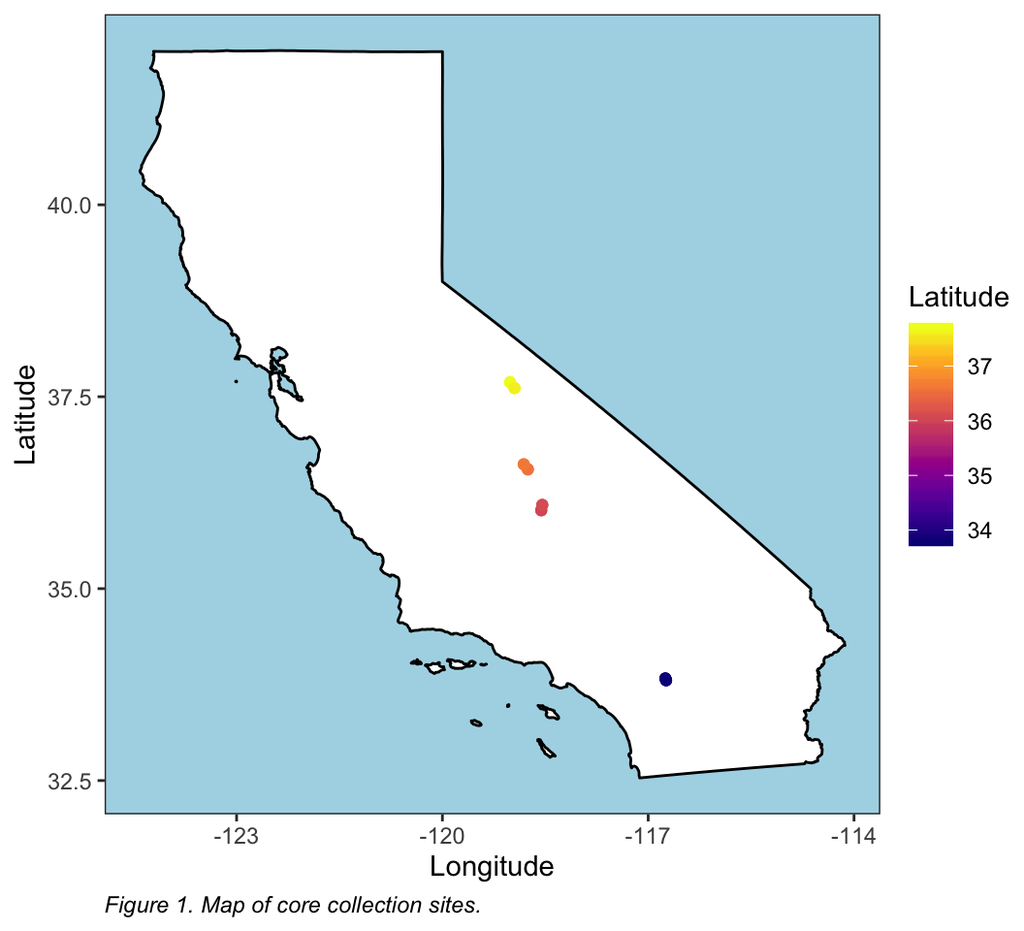

#### Preparation, crossdating, detrending

Samples were prepared with standard methods outlined in (Speer 2012). Samples were imaged and crossdated in the CDendro program. I performend additional crossdating and detrending with the ‘dplR’ package in R. I used a 30-year spline and performed subsequent analyses on the detrended individual tree growth.

##### Crossdating summary stats

San Jacinto

| site | n.cores | n.trees | n | n.tot | n.wt | n.bt | rbar.tot | rbar.wt | rbar.bt | c.eff | rbar.eff | eps | snr |
| --- | --- | --- | --- | --- | --- | --- | --- | --- | --- | --- | --- | --- | --- |
| seven pines | 59 | 29 | 11.472 | 1505 | 29 | 1476 | 0.330 | 0.642 | 0.324 | 1.953 | 0.392 | 0.881 | 7.401 |
| black mountain | 67 | 32 | 8.727 | 2080 | 38 | 2042 | 0.285 | 0.533 | 0.281 | 2.055 | 0.369 | 0.836 | 5.105 |

Sequoia National Forest

| site | n.cores | n.trees | n | n.tot | n.wt | n.bt | rbar.tot | rbar.wt | rbar.bt | c.eff | rbar.eff | eps | snr |
| --- | --- | --- | --- | --- | --- | --- | --- | --- | --- | --- | --- | --- | --- |
| lilly creek | 58 | 29 | 8.939 | 1539 | 28 | 1511 | 0.291 | 0.598 | 0.285 | 2.000 | 0.357 | 0.832 | 4.964 |
| peppermint | 59 | 29 | 9.841 | 1584 | 32 | 1552 | 0.271 | 0.570 | 0.265 | 1.931 | 0.334 | 0.832 | 4.941 |

Sequoia National Park

| site | n.cores | n.trees | n | n.tot | n.wt | n.bt | rbar.tot | rbar.wt | rbar.bt | c.eff | rbar.eff | eps | snr |
| --- | --- | --- | --- | --- | --- | --- | --- | --- | --- | --- | --- | --- | --- |
| crescent meadow | 55 | 29 | 13.211 | 1485 | 27 | 1458 | 0.206 | 0.516 | 0.200 | 1.776 | 0.254 | 0.818 | 4.489 |
| pine ridge | 56 | 29 | 9.782 | 1257 | 24 | 1233 | 0.151 | 0.476 | 0.145 | 1.800 | 0.189 | 0.695 | 2.281 |

Mammoth Lakes

| site | n.cores | n.trees | n | n.tot | n.wt | n.bt | rbar.tot | rbar.wt | rbar.bt | c.eff | rbar.eff | eps | snr |
| --- | --- | --- | --- | --- | --- | --- | --- | --- | --- | --- | --- | --- | --- |
| inyo craters | 68 | 33 | 8.006 | 1957 | 35 | 1922 | 0.189 | 0.496 | 0.183 | 2.044 | 0.246 | 0.723 | 2.616 |
| sherwin lakes | 56 | 29 | 9.431 | 1519 | 27 | 1492 | 0.392 | 0.603 | 0.388 | 1.871 | 0.476 | 0.896 | 8.572 |

#### Drought selection and index calculation.

I used the Standardized Precipitation-Evapotranspiration Index (SPEI) as a measure of water availability, or drought severity. To calculate SPEI I used monthly precipitation and temperature from 30 arc-second resolution PRISM data (PRISM, 2004) using the ‘spei’ package in R. Droughts were selected as the bottom 15<sup>th</sup> percentile SPEI years calcluated for each site individually. All calculations were based on the hydrologic year (September - August).

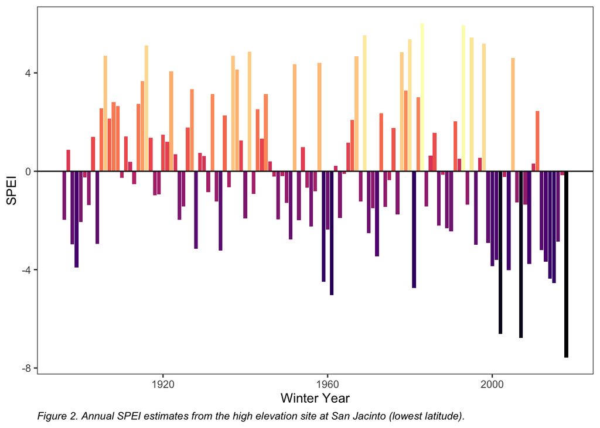

#### Modeling

To calculate $RWI_{pred}$ I modeled RWI as a function Species and SPEI I used the ‘brms’ package in R. For simplicity I denoted here site-specific regression coefficients, but they were modeled as elevation nested within region.
$$RWI_{pred_{i}} = \alpha_{site_{i}} + \beta_{1 site_{i}}*Species_{i} + \beta_{2site_{i}}*SPEI_{i} + \beta_{3site_{i}}*Species_{i}*SPEI_{i}$$

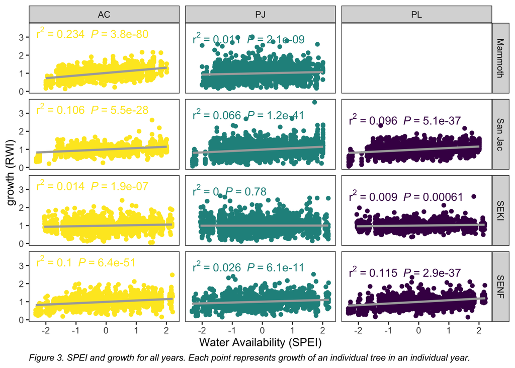

## Results

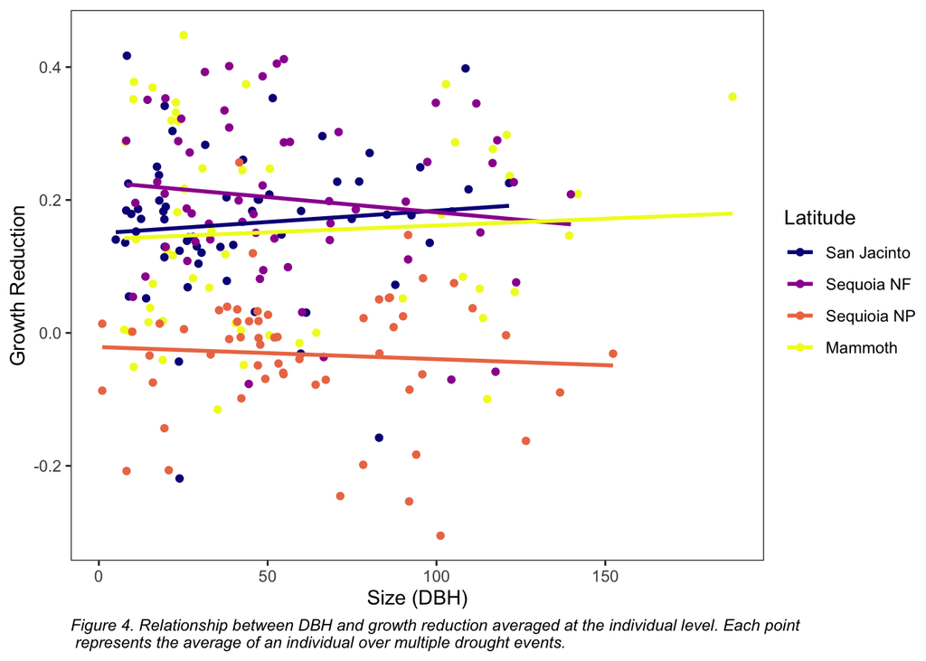

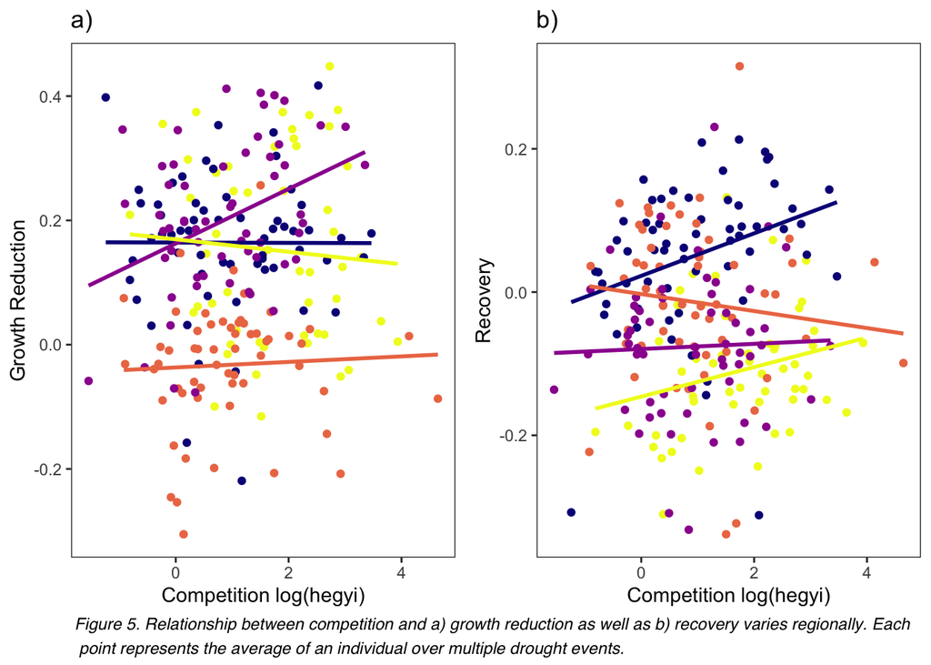

The following figures display the same relationships as the main figures from the poster, however the points are not summarized - each point represents a unique tree-year combination.

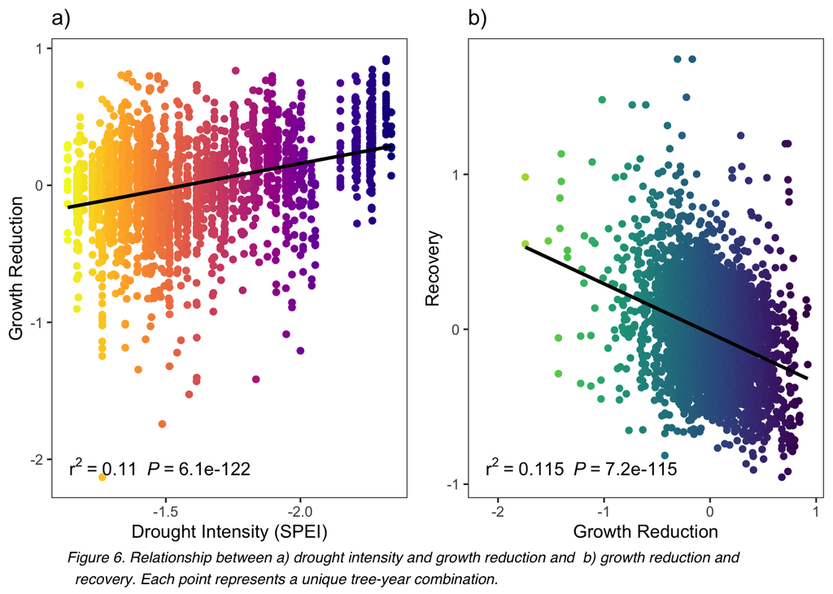

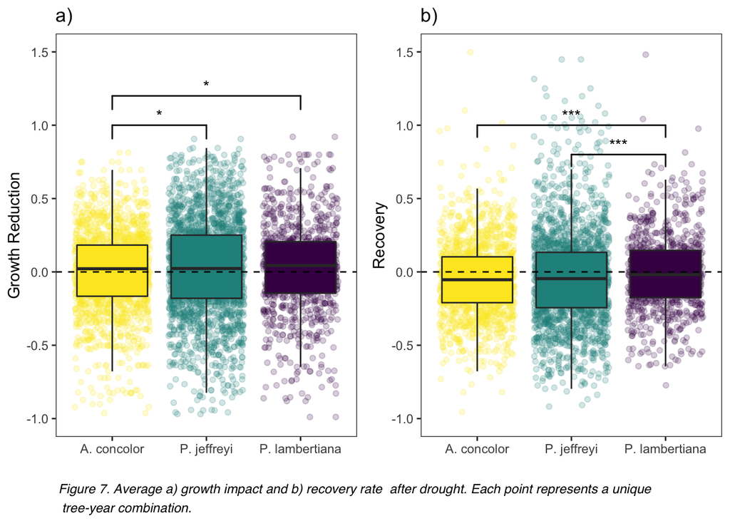